# Swordfern Mortality Sample Analyses

2025-11-14

```r
library(tidyverse)
library(kableExtra)
library(readr)
library(misty)
library(stringr)
library(BSDA)
library(car)
library(ggpubr)
library(statsExpressions)
library(RColorBrewer)
library(pillar)
library(readxl)
library(gridExtra)
library(rstatix)
library(Hotelling)
library(RVAideMemoire)
library(heplots)
library(effectsize)
library(npmv)
```

```r
#setwd("~/Library/Mobile Documents/com~apple~CloudDocs/Core/Server Files/swordfern")
data <- read.csv("~/GitHub/swordfern/data/lab/combined.results.csv")
```

```r
data <- rename(data,Tentative.Result = Tentative.Results..Internal.NCBI.Oomcycete.including.voucher.blast..x)
```

```r
data <- data %>% filter(common_name.x=="western sword fern")
```

```r
data$Tentative.Result[data$Tentative.Result=="Phytophthora europaea or abietivora?"] <- "Phytophthora sp."
data$Tentative.Result[data$Tentative.Result=="Phytophthora flexuosa?"] <- "Phytophthora sp."
```

```r
data$Project <- as.factor(data$Project)
data$place_guess.x <- as.factor(data$place_guess.x)
data$Oomycete.x <- as.factor(data$Oomycete.x)
```

```r
field.baits <- data %>% filter(Project=="Swordfern Soil Bait Isolates")
```

```r
roots <- data %>% filter(Project=="Swordfern Roots")
```

## Number of Isolates

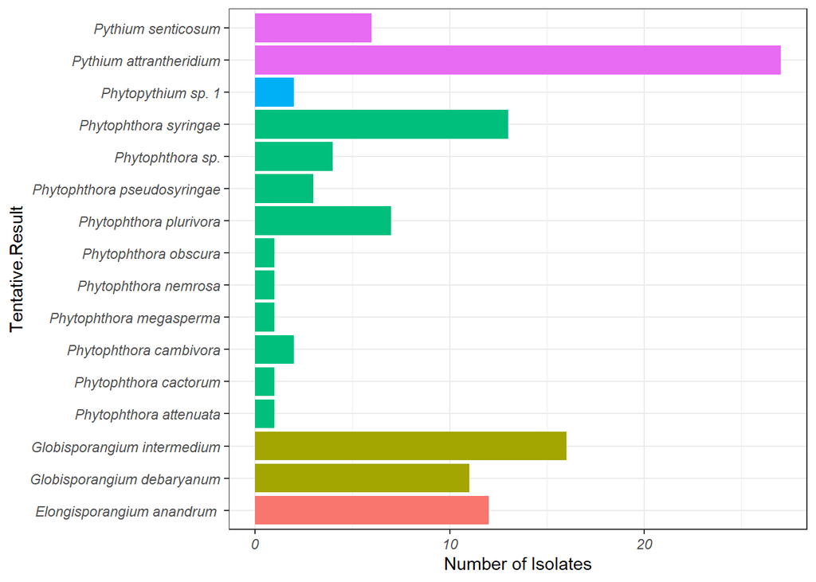

```r
ggplot(field.baits[field.baits$Tentative.Result!="" & !is.na(field.baits$Tentative.Result),],aes(Tentative.Result,fill=Genus.x)) +geom_histogram(stat="count")+coord_flip() +theme_bw() +guides(fill="none") +theme(axis.text = element_text(face = "italic")) + labs(y="Number of Isolates")
```

```r
levels(field.baits$Oomycete)
```

## Summary Tables

### Sample Collections

```r
sample.summary <- field.baits %>% summarize(n.sites = n_distinct(place_guess.x,na.rm=TRUE),n.samples=n_distinct(Sample),n.isolates=n(),n.oomycete.isolates=sum(Oomycete.x=="Oomycete",na.rm=TRUE),n.oomycete.spec=n_distinct(Tentative.Result),n.Phytoph.isolates=sum(Genus.x=="Phytophthora",na.rm=TRUE),n.Phytoph.spec=n_distinct(Tentative.Result[Genus.x=="Phytophthora" & !is.na(Tentative.Result)]),Phytoph.spp=paste(unique(Tentative.Result[Genus.x=="Phytophthora" & !is.na(Tentative.Result)]),collapse=", "))

kable(sample.summary,digits = 2) %>% kable_material(c("striped", "hover","condensed")) %>% kable_styling(full_width = F) %>% scroll_box(height = "400px")
```

| n.sites | n.samples | n.isolates | n.oomycete.isolates | n.oomycete.spec | n.Phytoph.isolates | n.Phytoph.spec | Phytoph.spp |
| --- | --- | --- | --- | --- | --- | --- | --- |
| 12 | 104 | 189 | 108 | 18 | 34 | 10 | Phytophthora syringae, Phytophthora sp., Phytophthora megasperma, Phytophthora plurivora, Phytophthora cactorum, Phytophthora pseudosyringae, Phytophthora cambivora, Phytophthora obscura, Phytophthora… |

### Phytophthora Isolates

```r
Phytophthora.summary <- field.baits %>% filter(Genus.x=="Phytophthora") %>% summarize(n.sites = n_distinct(place_guess.x,na.rm=TRUE),n.samples=n_distinct(Sample),n.isolates=n(),n.oomycete.isolates=sum(Oomycete.x=="Oomycete",na.rm=TRUE),n.oomycete.spec=n_distinct(Tentative.Result),n.Phytoph.isolates=sum(Genus.x=="Phytophthora",na.rm=TRUE),n.Phytoph.spec=n_distinct(Tentative.Result[Genus.x=="Phytophthora" & !is.na(Tentative.Result)]),Phytoph.spp=paste(unique(Tentative.Result[Genus.x=="Phytophthora" & !is.na(Tentative.Result)]),collapse=", "))

kable(Phytophthora.summary,digits = 2) %>% kable_material(c("striped", "hover","condensed")) %>% kable_styling(full_width = F) %>% scroll_box(height = "400px")
```

| n.sites | n.samples | n.isolates | n.oomycete.isolates | n.oomycete.spec | n.Phytoph.isolates | n.Phytoph.spec | Phytoph.spp |
| --- | --- | --- | --- | --- | --- | --- | --- |
| 8 | 28 | 34 | 34 | 10 | 34 | 10 | Phytophthora syringae, Phytophthora sp., Phytophthora megasperma, Phytophthora plurivora, Phytophthora cactorum, Phytophthora pseudosyringae, Phytophthora cambivora, Phytophthora obscura, Phytophthora… |

### Samples per ‘place guess’

```r
site.summary <- field.baits %>% group_by(place_guess.x) %>% summarize(n.samples=n_distinct(Sample),n.isolates=n(),n.oomycete.isolates=sum(Oomycete.x=="Oomycete",na.rm=TRUE),n.oomycete.spec=n_distinct(Tentative.Result),n.Phytoph.isolates=sum(Genus.x=="Phytophthora",na.rm=TRUE),n.Phytoph.spec=n_distinct(Tentative.Result[Genus.x=="Phytophthora" & !is.na(Tentative.Result)]),Phytoph.spp=paste(unique(Tentative.Result[Genus.x=="Phytophthora" & !is.na(Tentative.Result)]),collapse=", "))
kable(site.summary,digits = 2) %>% kable_material(c("striped", "hover","condensed")) %>% kable_styling(full_width = F) %>% scroll_box(height = "400px")
```

| place_guess.x | n.samples | n.isolates | n.oomycete.isolates | n.oomycete.spec | n.Phytoph.isolates | n.Phytoph.spec | Phytoph.spp |
| --- | --- | --- | --- | --- | --- | --- | --- |
| Bainbridge Island, Bainbridge Island, WA, US | 6 | 9 | 6 | 5 | 1 | 1 | Phytophthora syringae |
| Blakely Harbor, Bainbridge Island, WA, US | 9 | 17 | 11 | 7 | 2 | 2 | Phytophthora syringae, Phytophthora megasperma |
| Four Hundred Sixty-Second Street East, Eatonville, WA, US | 4 | 10 | 7 | 4 | 5 | 2 | Phytophthora plurivora, Phytophthora cactorum |
| Keller Ln, Port Ludlow, WA, US | 1 | 2 | 2 | 1 | 0 | 0 |  |
| Mercer Island, Mercer Island, WA, US | 16 | 30 | 18 | 8 | 5 | 2 | Phytophthora syringae, Phytophthora sp. |
| Morganmarsh Ln W, Seabeck, WA, US | 13 | 18 | 8 | 5 | 0 | 0 |  |
| NE Mountain Lake Dr, Belfair, WA, US | 12 | 23 | 17 | 11 | 5 | 4 | Phytophthora obscura, Phytophthora pseudosyringae, Phytophthora plurivora, Phytophthora attenuata |
| Oak Bay Rd, Port Ludlow, WA, US | 4 | 6 | 4 | 4 | 0 | 0 |  |
| Olympic Pl, Port Ludlow, WA, US | 2 | 4 | 1 | 2 | 0 | 0 |  |
| SE 158th St, Issaquah, WA, US | 13 | 29 | 12 | 11 | 6 | 5 | Phytophthora pseudosyringae, Phytophthora plurivora, Phytophthora cambivora, Phytophthora syringae, Phytophthora sp. |
| Seward Park, Seattle, WA, US | 15 | 24 | 16 | 8 | 8 | 2 | Phytophthora syringae, Phytophthora sp. |
| Tradition Plateau NRCA, Issaquah, WA, US | 9 | 17 | 6 | 6 | 2 | 2 | Phytophthora plurivora, Phytophthora nemrosa |

```r
species.summary <- field.baits %>% filter(!is.na(Tentative.Result) & Tentative.Result!="") %>% group_by(Tentative.Result) %>% summarize(n.sites = n_distinct(place_guess.x,na.rm=TRUE),n.samples = n_distinct(Sample,na.rm=TRUE),n.isolates=n(),Genus.x=paste(unique(Genus.x)))

kable(species.summary, digits = 2) %>% kable_material(c("striped", "hover","condensed")) %>% kable_styling(full_width = F) %>% scroll_box(height = "400px")
```

| Tentative.Result | n.sites | n.samples | n.isolates | Genus.x |
| --- | --- | --- | --- | --- |
| Elongisporangium anandrum | 5 | 8 | 12 | Elongisporangium |
| Globisporangium debaryanum | 6 | 8 | 11 | Globisporangium |
| Globisporangium intermedium | 7 | 15 | 16 | Globisporangium |
| Phytophthora attenuata | 1 | 1 | 1 | Phytophthora |
| Phytophthora cactorum | 1 | 1 | 1 | Phytophthora |
| Phytophthora cambivora | 1 | 1 | 2 | Phytophthora |
| Phytophthora megasperma | 1 | 1 | 1 | Phytophthora |
| Phytophthora nemrosa | 1 | 1 | 1 | Phytophthora |
| Phytophthora obscura | 1 | 1 | 1 | Phytophthora |
| Phytophthora plurivora | 4 | 6 | 7 | Phytophthora |
| Phytophthora pseudosyringae | 2 | 3 | 3 | Phytophthora |
| Phytophthora sp. | 3 | 4 | 4 | Phytophthora |
| Phytophthora syringae | 5 | 11 | 13 | Phytophthora |
| Phytopythium sp. 1 | 2 | 2 | 2 | Phytopythium |
| Pythium attrantheridium | 9 | 23 | 27 | Pythium |
| Pythium senticosum | 3 | 6 | 6 | Pythium |

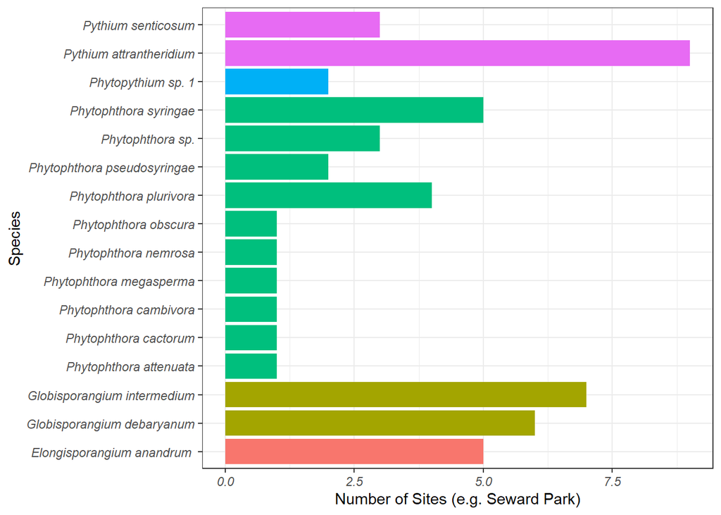

```r
ggplot(species.summary,aes(Tentative.Result,n.sites,fill=Genus.x)) +geom_col() +theme_bw() +coord_flip() + guides(fill=FALSE) +theme(axis.text = element_text(face = "italic")) +labs(x="Species",y="Number of Sites (e.g. Seward Park)")
```

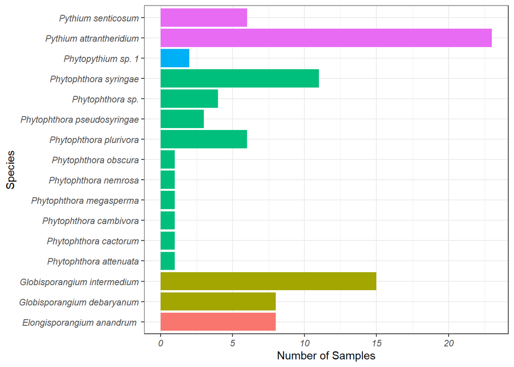

```r
ggplot(species.summary,aes(Tentative.Result,n.samples,fill=Genus.x)) +geom_col() +theme_bw() +coord_flip() + guides(fill=FALSE) +theme(axis.text = element_text(face = "italic")) +labs(x="Species",y="Number of Samples")
```

```r
species.summary <- field.baits %>% filter(!is.na(Tentative.Result) & Tentative.Result!="") %>% group_by(site.location.description.x,Tentative.Result) %>% summarize(n.sites = n_distinct(place_guess.x,na.rm=TRUE),n.samples = n_distinct(Sample,na.rm=TRUE),n.isolates=n(),Genus.x=paste(unique(Genus.x)))
```

```
## `summarise()` has regrouped the output.
## ℹ Summaries were computed grouped by site.location.description.x and
##   Tentative.Result.
## ℹ Output is grouped by site.location.description.x.
## ℹ Use `summarise(.groups = "drop_last")` to silence this message.
## ℹ Use `summarise(.by = c(site.location.description.x, Tentative.Result))` for
##   per-operation grouping (`?dplyr::dplyr_by`) instead.
```

```r
species.summary
```

```
## # A tibble: 36 × 6
## # Groups:   site.location.description.x [4]
##    site.location.descrip…¹ Tentative.Result n.sites n.samples n.isolates Genus.x
##    <chr>                   <chr>              <int>     <int>      <int> <chr>
##  1 Forest edge             "Elongisporangi…       1         2          3 Elongi…
##  2 Forest edge             "Globisporangiu…       2         3          3 Globis…
##  3 Forest edge             "Globisporangiu…       3         4          5 Globis…
##  4 Forest edge             "Phytophthora a…       1         1          1 Phytop…
##  5 Forest edge             "Phytophthora c…       1         1          2 Phytop…
##  6 Forest edge             "Phytophthora m…       1         1          1 Phytop…
##  7 Forest edge             "Phytophthora n…       1         1          1 Phytop…
##  8 Forest edge             "Phytophthora p…       3         3          3 Phytop…
##  9 Forest edge             "Phytophthora p…       2         2          2 Phytop…
## 10 Forest edge             "Phytophthora s…       1         1          1 Phytop…
## # ℹ 26 more rows
## # ℹ abbreviated name: ¹site.location.description.x
```

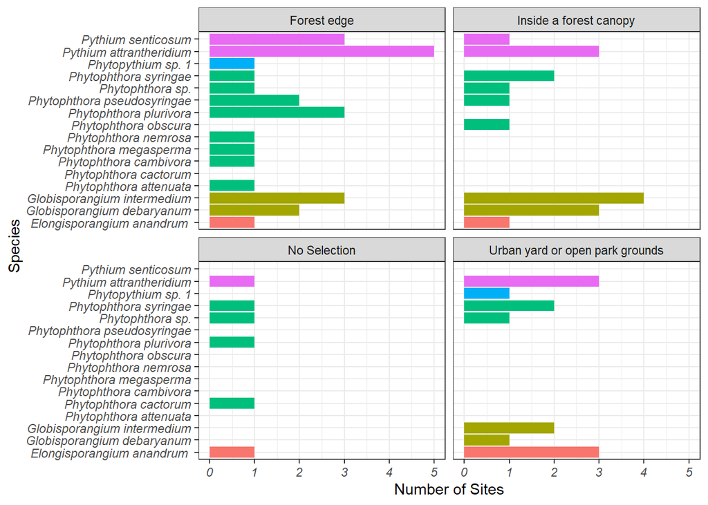

```r
ggplot(species.summary,aes(Tentative.Result,n.sites,fill=Genus.x)) +geom_col() +facet_wrap(~site.location.description.x) +theme_bw() +coord_flip() + guides(fill=FALSE) +theme(axis.text = element_text(face = "italic")) +labs(x="Species",y="Number of Sites")
```

```r
names(field.baits)
```

```
##  [1] "X.1"
##  [2] "X"
##  [3] "Isolate.ID"
##  [4] "Project"
##  [5] "Primary.ioslation.date"
##  [6] "Date.Extracted.x"
##  [7] "Date"
##  [8] "Location"
##  [9] "Current.Isolate.Status"
## [10] "Phytophthora.likely.x"
## [11] "Morphology"
## [12] "Species"
## [13] "Ready.to.Extract"
## [14] "Media"
## [15] "Backup.Location"
```

[output cut: 76 more lines]

```r
str(field.baits$percent.of.plants..of.same.species..affected.within.sight.....y)
```

```
##  int [1:189] 5 5 5 5 15 15 15 3 5 5 ...
```

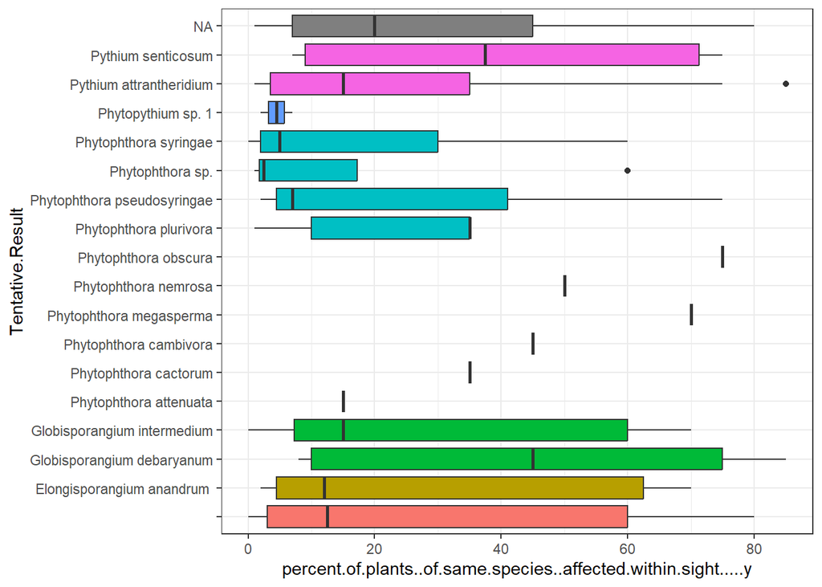

```r
ggplot(field.baits,aes(Tentative.Result,percent.of.plants..of.same.species..affected.within.sight.....y ,fill=Genus.x)) +geom_boxplot()+coord_flip()+theme_bw()+guides(fill="none")
```

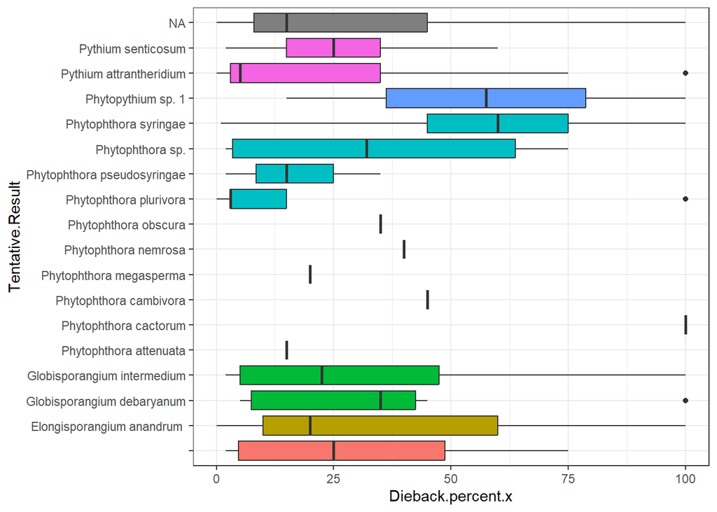

```r
ggplot(field.baits,aes(Tentative.Result,Dieback.percent.x,fill=Genus.x)) +geom_boxplot()+coord_flip()+theme_bw()+guides(fill="none")
```

# Greenhouse data

## Seward Soil Trials

### Data Visualization

Visualize data for Seward soil trials by comparing weights and number of fronds (total, healthy, and unhealthy) between treatment groups (control - potting mix, sterilized, wild).

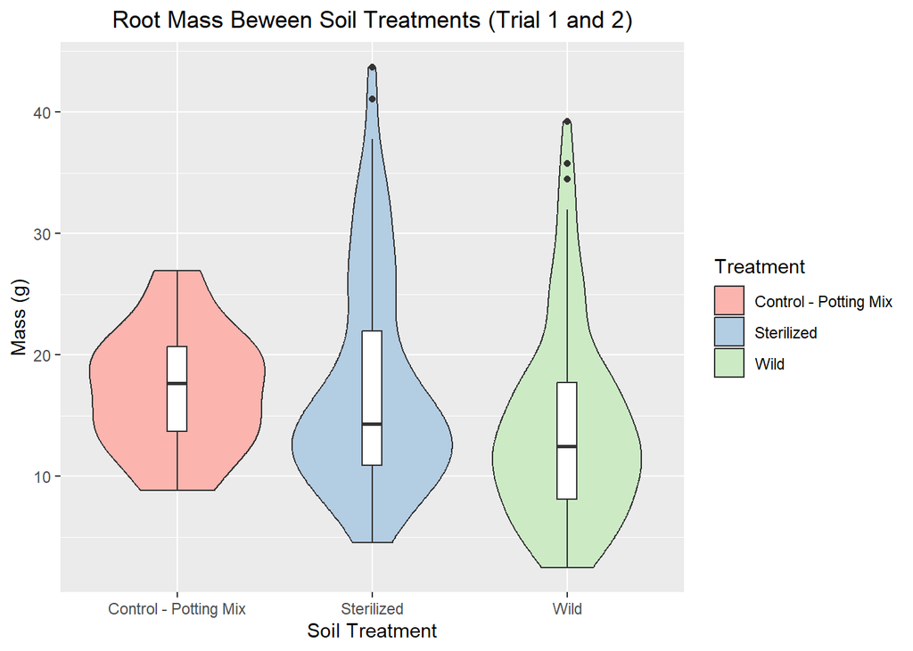

```r
greenhouse.data <- read.csv("~/GitHub/swordfern/data/greenhouse/Final-Greenhouse-Data-Combined.csv")
greenhouse.data <- rename(greenhouse.data, "Weight" = "Weight..g.")
greenhouse.data$Total.Fronds <- greenhouse.data$Healthy.Fronds + greenhouse.data$Crispy.Fronds

seward.data <- greenhouse.data %>% filter(Experiment == "Seward Soil")

seward.roots.plot <- ggplot(seward.data, aes(x = Treatment, y = Weight, fill = Treatment)) + geom_violin() +geom_boxplot(width = 0.1, fill = "white") + labs(title = "Root Mass Beween Soil Treatments (Trial 1 and 2)", y = "Mass (g)", x = "Soil Treatment") + theme(plot.title =  element_text(hjust = 0.5))
seward.roots.plot + scale_fill_brewer(palette = "Pastel1")
```

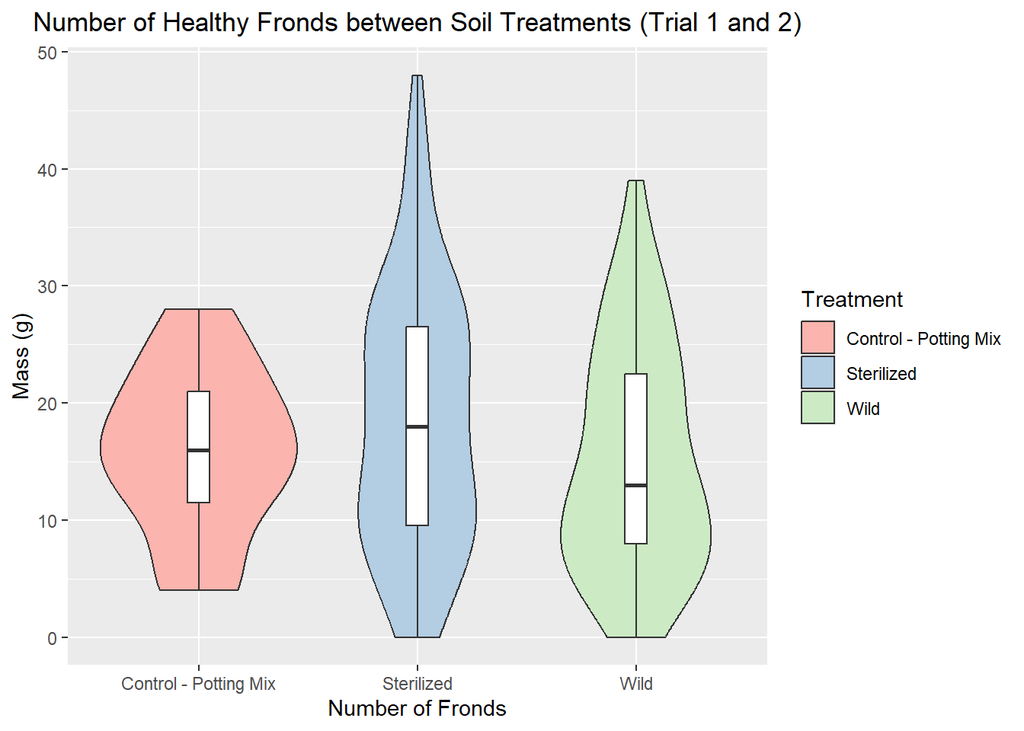

```r
seward.healthy <- ggplot(seward.data, aes(x = Treatment, y = Healthy.Fronds, fill = Treatment)) + geom_violin() + geom_boxplot(width = 0.1, fill = "white") + labs(title = "Number of Healthy Fronds between Soil Treatments (Trial 1 and 2)", y = "Mass (g)", x = "Number of Fronds") + theme(plot.title = element_text(hjust = 0.5))
seward.healthy + scale_fill_brewer(palette = "Pastel1")
```

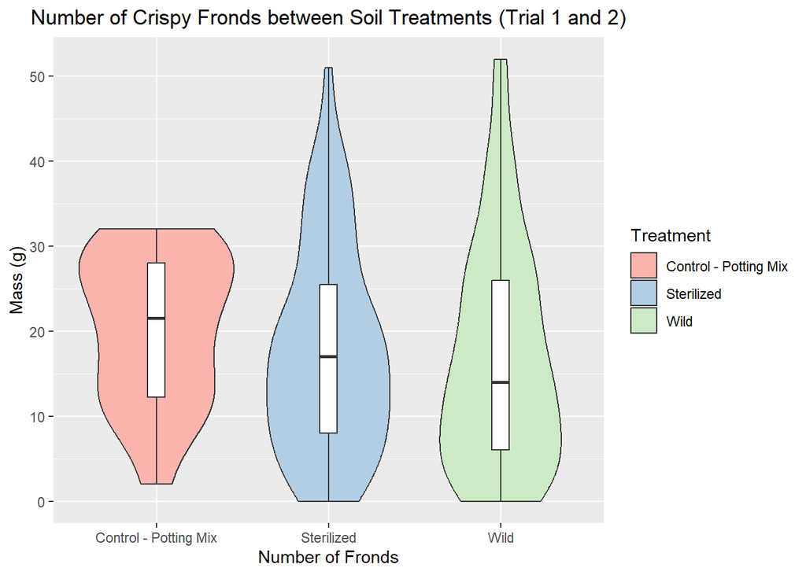

```r
seward.crispy <- ggplot(seward.data, aes(x = Treatment, y = Crispy.Fronds , fill = Treatment)) + geom_violin() + geom_boxplot(width = 0.1, fill = "white") + labs(title = "Number of Crispy Fronds between Soil Treatments (Trial 1 and 2)", y = "Mass (g)", x = "Number of Fronds") + theme(plot.title = element_text(hjust = 0.5))
seward.crispy + scale_fill_brewer(palette = "Pastel1")
```

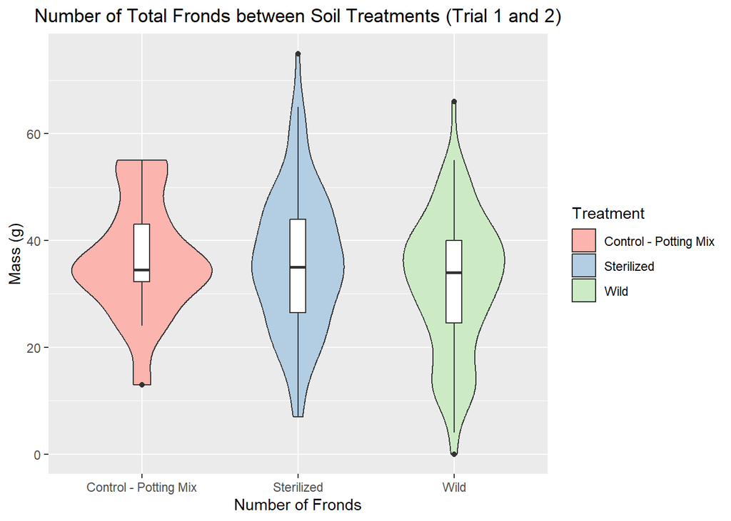

```r
seward.total <- ggplot(seward.data, aes(x = Treatment, y = Total.Fronds , fill = Treatment)) + geom_violin() + geom_boxplot(width = 0.1, fill = "white") + labs(title = "Number of Total Fronds between Soil Treatments (Trial 1 and 2)", y = "Mass (g)", x = "Number of Fronds") + theme(plot.title = element_text(hjust = 0.5))
seward.total + scale_fill_brewer(palette = "Pastel1")
```

## Seward Trial 1

```r
seward1 <- seward.data %>% filter(Trial.x == "Seward Trial One")

leveneTest(Total.Fronds ~ as.factor(Treatment), data = seward1, na.rm = TRUE)
```

```
## Levene's Test for Homogeneity of Variance (center = median: TRUE)
##       Df F value Pr(>F)
## group  1  0.4325 0.5125
##       84
```

```r
leveneTest(Weight ~ as.factor(Treatment), data = seward1, na.rm = TRUE)
```

```
## Levene's Test for Homogeneity of Variance (center = median: TRUE)
##       Df F value Pr(>F)
## group  1  1.8192  0.181
##       84
```

There is not enough evidence to reject equality of vairances between treatment groups for the total number of fronds and dry root weights.

### Check for normality

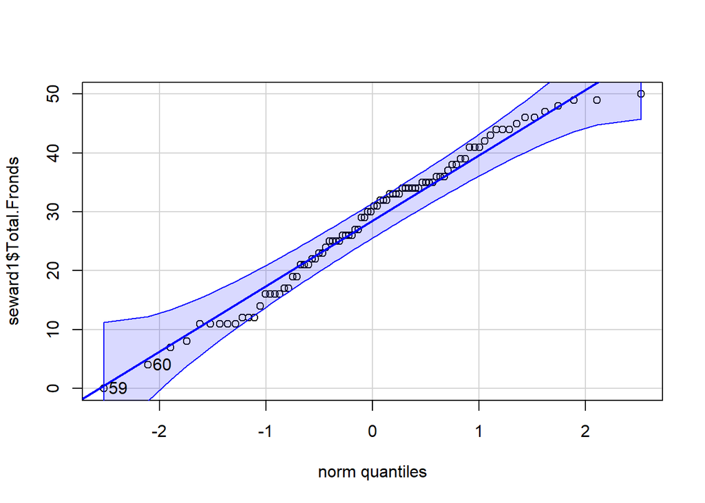

```
## [1] 59 60
```

```r
qqPlot(seward1$Total.Fronds)
```

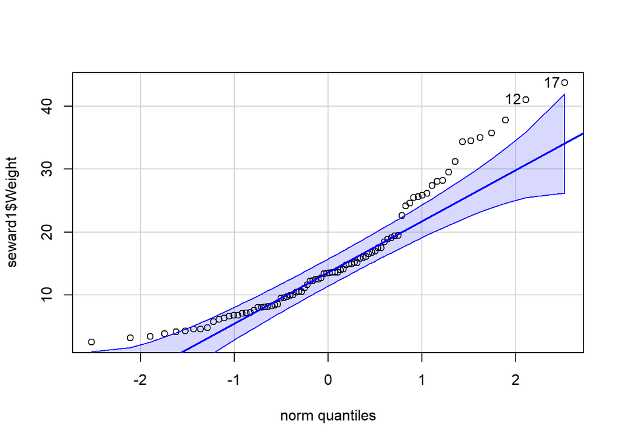

```
## [1] 17 12
```

```r
qqPlot(seward1$Weight)
```

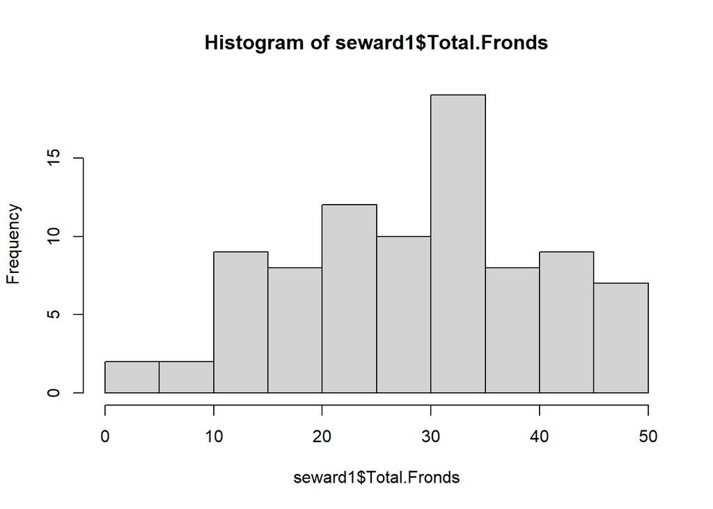

```r
hist(seward1$Total.Fronds)
```

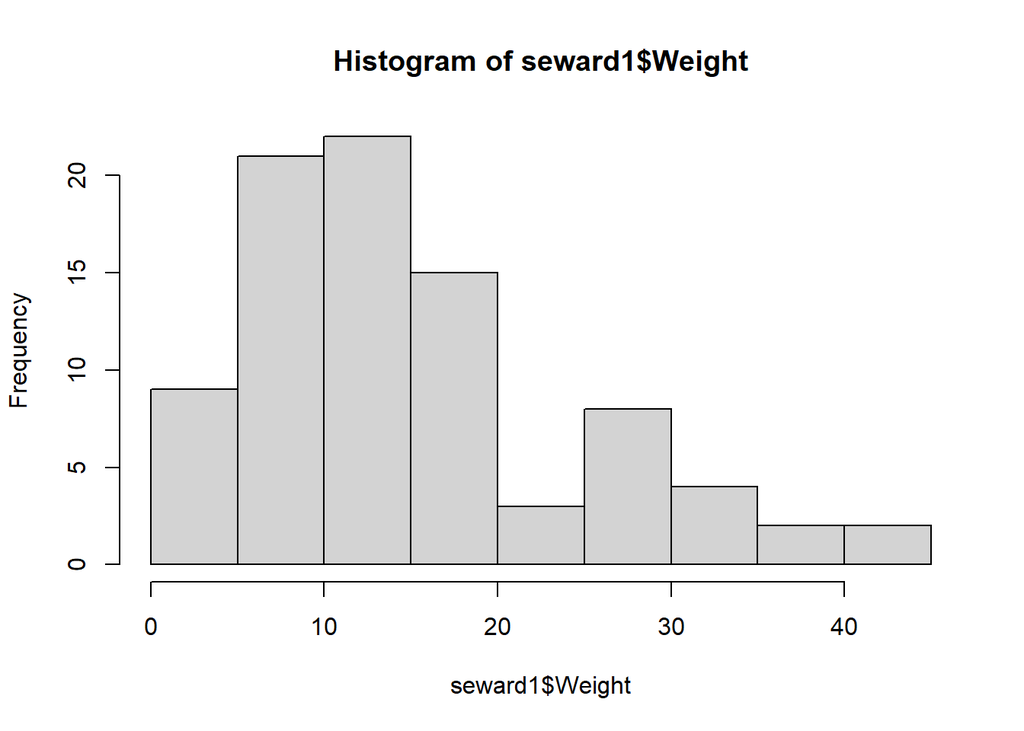

```r
hist(seward1$Weight)
```

```r
seward1 %>% shapiro_test(Total.Fronds, Weight)
```

```
## # A tibble: 2 × 3
##   variable     statistic         p
##   <chr>            <dbl>     <dbl>
## 1 Total.Fronds     0.977 0.125
## 2 Weight           0.905 0.0000108
```

Dry swordfern root weight data not normally distributed according to visual inspection using qqPlot and histogram and the Shapiro-Wilk test for normality.

### Run non-parametric Inference for Multivariate Data on Seward Trial 1 data

```r
set.seed(123)
seward1.npmv <- nonpartest(Total.Fronds | Weight ~ Treatment, data = seward1, permtest = TRUE, plots = F, tests = c(1, 1, 1, 1), releffects = TRUE)
seward1.npmv
```

```
## $results
##                                                   Test Statistic   df1      df2
## ANOVA type test p-value                                    5.345 1.750 146.9718
## McKeon approx. for the Lawley Hotelling Test               3.975 2.000  83.0000
## Muller approx. for the Bartlett-Nanda-Pillai Test          3.929 2.023  82.9880
## Wilks Lambda                                               3.975 2.000  83.0000
##                                                   P-value
## ANOVA type test p-value                             0.008
## McKeon approx. for the Lawley Hotelling Test        0.022
## Muller approx. for the Bartlett-Nanda-Pillai Test   0.023
## Wilks Lambda                                        0.022
##                                                   Permutation Test p-value
## ANOVA type test p-value                                              0.010
## McKeon approx. for the Lawley Hotelling Test                         0.024
## Muller approx. for the Bartlett-Nanda-Pillai Test                    0.024
## Wilks Lambda                                                         0.024
##
## $twogroupreleffects
##            Total.Fronds Weight
## Sterilized      0.61818 0.6609
## Wild            0.38182 0.3391
```

```r
seward.ss <- ssnonpartest(Total.Fronds | Weight ~ Treatment, data = seward1, test = c(0, 0, 0, 1), alpha = .05, factors.and.variables = FALSE)
```

```
##
## The Wilks' Lambda type statistic will be used in the following test
## The Global Hypothesis is significant, subset algorithm will continue
##
## ~Performing the Subset Algorithm based on Response Variables~
##  The Hypothesis of equality using response variables  Total.Fronds Weight is rejected
## The Hypothesis of equality using response variables  Weight is rejected
## All appropriate subsets using response variables have been checked using a multiple testing procedure, which controls the maximum overall type I error rate at alpha= 0.05
```

```r
seward.ss
```

[output not shown]

The probability that a randomly chosen plant from the sterilized soil group exhibits a greater number of fronds than a randomly chosen plant from the trial is 0.61818. The probability that a randomly chosen plant from the sterilized soil group exhibits a greater root mass than a randomly chosen plant from the trial is 0.6609.

## Seward Trial 2

### Subset data and check for equality of variances

```r
seward2 <- seward.data %>% filter(Trial.x == "Seward Trial Two")
seward2.nopot <- seward2 %>% filter(Treatment != "Control - Potting Mix")

leveneTest(Total.Fronds~as.factor(Treatment), data=seward2, na.rm = TRUE)
```

```
## Levene's Test for Homogeneity of Variance (center = median: TRUE)
##        Df F value Pr(>F)
## group   2  1.2392 0.2939
##       103
```

```r
leveneTest(Weight~as.factor(Treatment), data = seward2, na.rm = TRUE)
```

```
## Levene's Test for Homogeneity of Variance (center = median: TRUE)
##        Df F value Pr(>F)
## group   2  0.6963 0.5008
##       103
```

```r
leveneTest(Weight~as.factor(Treatment), data = seward2.nopot, na.rm = TRUE)
```

```
## Levene's Test for Homogeneity of Variance (center = median: TRUE)
##       Df F value Pr(>F)
## group  1  0.1965 0.6586
##       86
```

```r
leveneTest(Total.Fronds~as.factor(Treatment), data = seward2.nopot, na.rm = TRUE)
```

```
## Levene's Test for Homogeneity of Variance (center = median: TRUE)
##       Df F value Pr(>F)
## group  1  2.0327 0.1576
##       86
```

There is not enough evidence to reject equality of variances between treatment groups.

### Check for normality

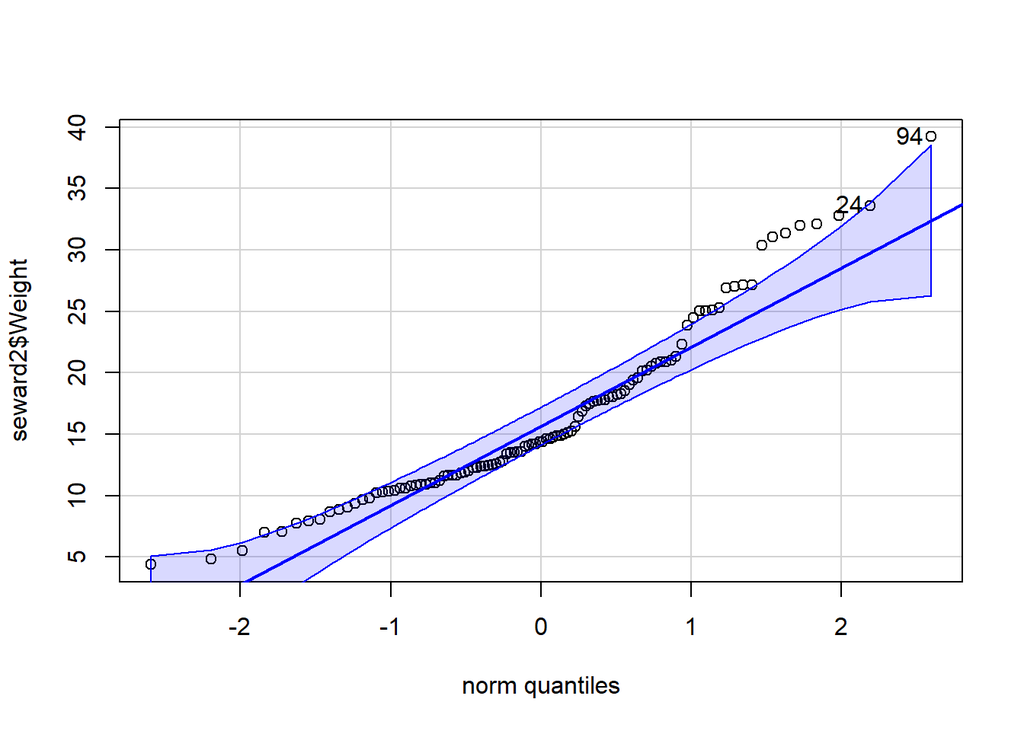

```
## [1] 94 24
```

```r
qqPlot(seward2$Weight)
```

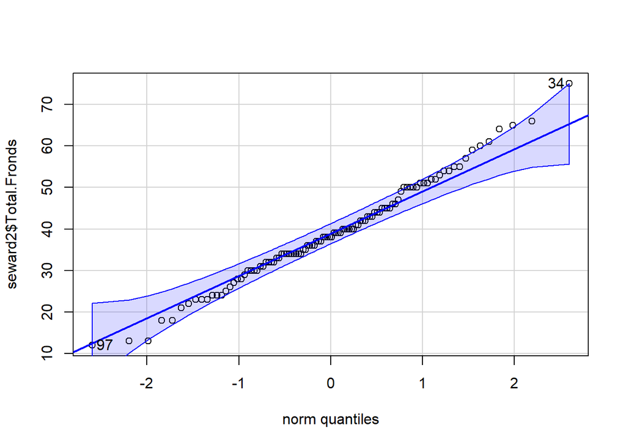

```
## [1] 34 97
```

```r
qqPlot(seward2$Total.Fronds)
```

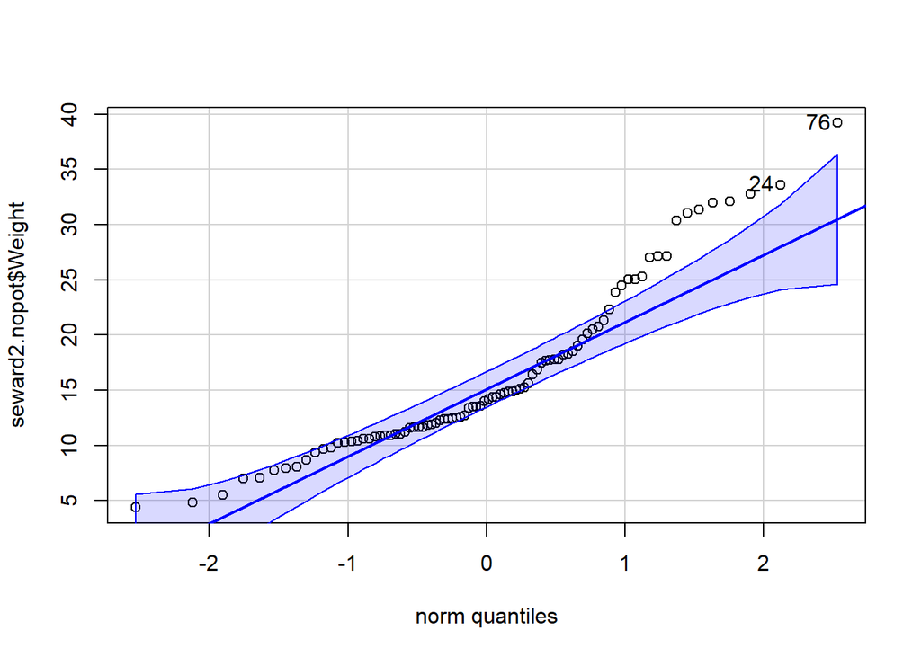

```
## [1] 76 24
```

```r
qqPlot(seward2.nopot$Weight)
```

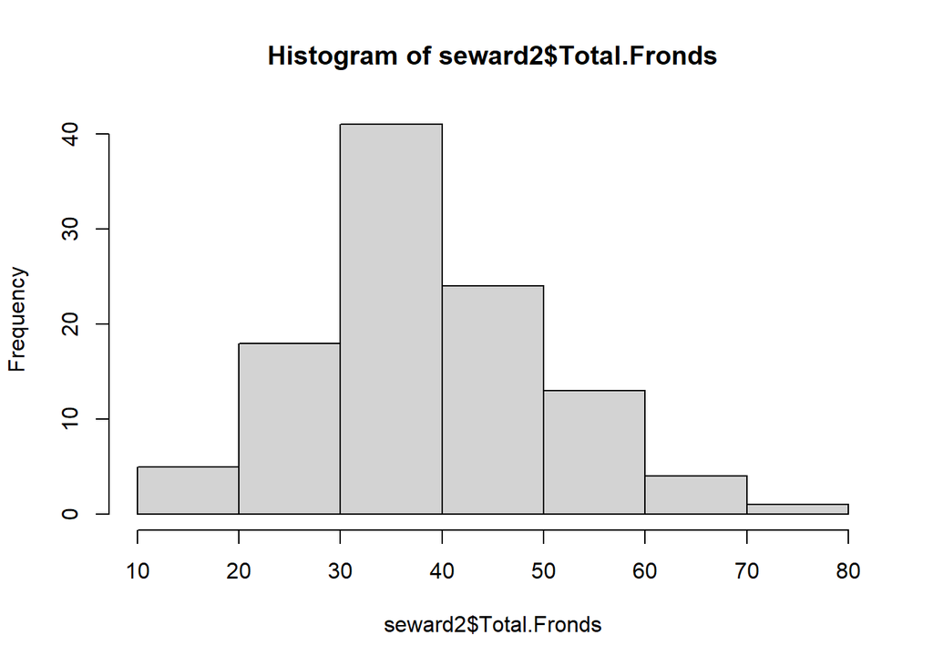

```r
hist(seward2$Total.Fronds)
```

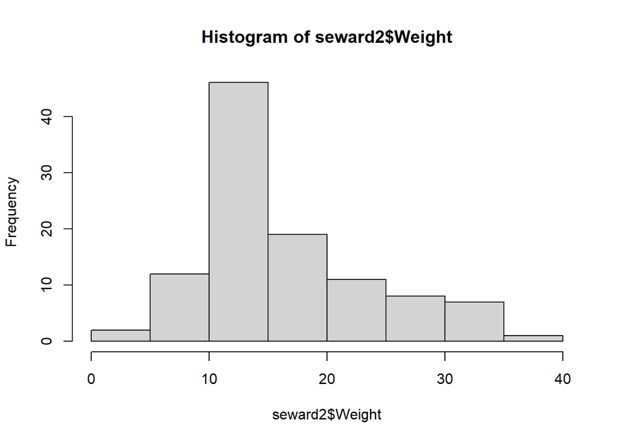

```r
hist(seward2$Weight)
```

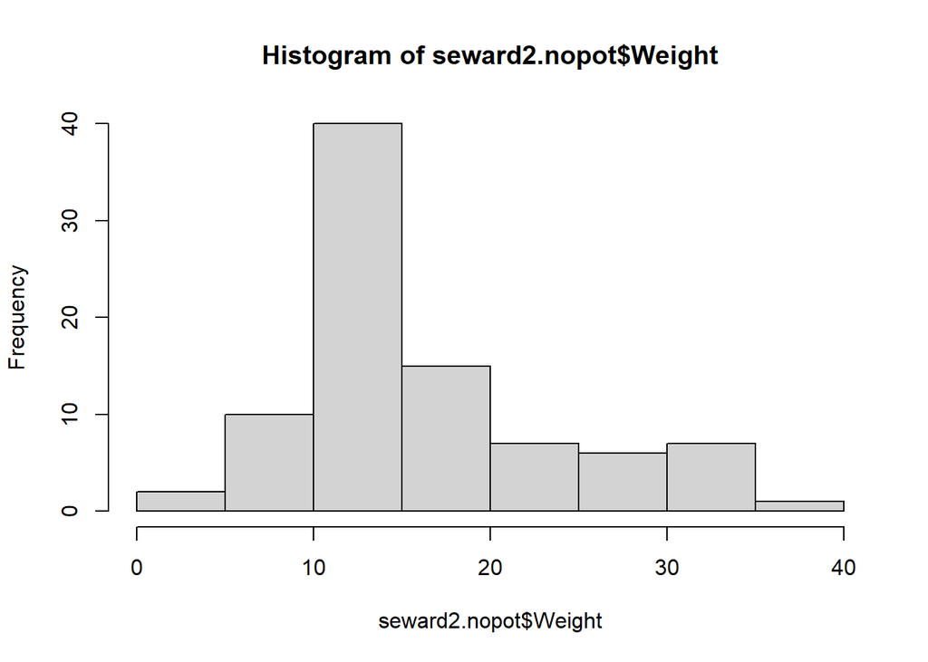

```r
hist(seward2.nopot$Weight)
```

```r
seward2 %>% shapiro_test(Total.Fronds, Weight)
```

```
## # A tibble: 2 × 3
##   variable     statistic         p
##   <chr>            <dbl>     <dbl>
## 1 Total.Fronds     0.990 0.593
## 2 Weight           0.927 0.0000196
```

Dry swordfern root weight data not normally distributed according to visual inspection using qqPlot and histogram and the Shapiro-Wilk test for normality.

### Run non-parametric Inference for Multivariate Data on Seward Trail 2 data

```r
set.seed(123)
seward2.npmv <- nonpartest(Total.Fronds | Weight ~ Treatment, data = seward2, permtest = TRUE, plots = F, tests = c(1, 1, 1, 1), releffects = TRUE)
seward2.npmv
```

```
## $results
##                                                   Test Statistic   df1      df2
## ANOVA type test p-value                                    1.225 3.566 152.3555
## McKeon approx. for the Lawley Hotelling Test               1.269 4.000 121.3676
## Muller approx. for the Bartlett-Nanda-Pillai Test          1.261 4.116 209.9615
## Wilks Lambda                                               1.267 4.000 204.0000
##                                                   P-value
## ANOVA type test p-value                             0.303
## McKeon approx. for the Lawley Hotelling Test        0.286
## Muller approx. for the Bartlett-Nanda-Pillai Test   0.286
## Wilks Lambda                                        0.284
##                                                   Permutation Test p-value
## ANOVA type test p-value                                              0.301
## McKeon approx. for the Lawley Hotelling Test                         0.286
## Muller approx. for the Bartlett-Nanda-Pillai Test                    0.283
## Wilks Lambda                                                         0.284
##
## $releffects
##                       Total.Fronds  Weight
## Control - Potting Mix      0.43606 0.58150
## Sterilized                 0.54031 0.50472
## Wild                       0.48585 0.46194
```

```r
seward.ss <- ssnonpartest(Total.Fronds | Weight ~ Treatment, data = seward2, test = c(0, 0, 0, 1), alpha = .05, factors.and.variables = FALSE)
```

```
##
## The Wilks' Lambda type statistic will be used in the following test
```

```r
seward.ss
```

```
## [1] "The Global Hypothesis is not significant, subset algorithm will not continue"
```

It is possible to run all non-parametric statistical analyses on our Seward trial 2 dataset, but we will focus on the Wilks Lambda type statistic as it is the most robust against Type I and Type II errors. Since our dataset contains over 30 samples, we can perform an F approximation to calculate a p-value for our statistical test. The Wilks Lambda type test suggests that there is no significant difference in the multivariate distributions between treatment groups.

### Excluding potting soil control group

```r
set.seed(123)
seward2.nopot.npmv <- nonpartest(Total.Fronds | Weight ~ Treatment, data = seward2.nopot, permtest = TRUE, plots = F, tests = c(1, 1, 1, 1), releffects = TRUE)
seward2.nopot.npmv
```

```
## $results
##                                                   Test Statistic   df1      df2
## ANOVA type test p-value                                    0.690 1.784 153.4028
## McKeon approx. for the Lawley Hotelling Test               0.522 2.000  85.0000
## Muller approx. for the Bartlett-Nanda-Pillai Test          0.516 2.023  84.9882
## Wilks Lambda                                               0.522 2.000  85.0000
##                                                   P-value
## ANOVA type test p-value                             0.487
## McKeon approx. for the Lawley Hotelling Test        0.595
## Muller approx. for the Bartlett-Nanda-Pillai Test   0.601
## Wilks Lambda                                        0.595
##                                                   Permutation Test p-value
## ANOVA type test p-value                                              0.488
## McKeon approx. for the Lawley Hotelling Test                         0.591
## Muller approx. for the Bartlett-Nanda-Pillai Test                    0.591
## Wilks Lambda                                                         0.591
##
## $twogroupreleffects
##            Total.Fronds Weight
## Sterilized       0.5594 0.5421
## Wild             0.4406 0.4579
```

```r
seward.nopot.ss <- ssnonpartest(Total.Fronds | Weight ~ Treatment, data = seward2.nopot, test = c(0, 0, 0, 1), alpha = .05, factors.and.variables = FALSE)
```

```
##
## The Wilks' Lambda type statistic will be used in the following test
```

```r
seward.nopot.ss
```

```
## [1] "The Global Hypothesis is not significant, subset algorithm will not continue"
```

## Seward Combined Trials (1 and 2)

### Check equality of variances (all treatment groups)

```r
leveneTest(Healthy.Fronds~as.factor(Treatment), data=seward.data, na.rm = TRUE)
```

```
## Levene's Test for Homogeneity of Variance (center = median: TRUE)
##        Df F value  Pr(>F)
## group   2  3.3896 0.03578 *
##       189
## ---
## Signif. codes:  0 '***' 0.001 '**' 0.01 '*' 0.05 '.' 0.1 ' ' 1
```

### Check equality of variances (Wild and Sterilized groups only)

```r
seward.nopot <- seward.data %>% filter(Treatment != "Control - Potting Mix")
leveneTest(Healthy.Fronds~as.factor(Treatment), data=seward.nopot, na.rm = TRUE)
```

```
## Levene's Test for Homogeneity of Variance (center = median: TRUE)
##        Df F value Pr(>F)
## group   1  1.7767 0.1843
##       172
```

```r
leveneTest(Crispy.Fronds~as.factor(Treatment), data=seward.nopot, na.rm = TRUE)
```

```
## Levene's Test for Homogeneity of Variance (center = median: TRUE)
##        Df F value Pr(>F)
## group   1  0.5275 0.4687
##       172
```

There is not enough evidence to reject equality of variances between the number of healthy and crispy fronds between treatment groups.

### Check normality

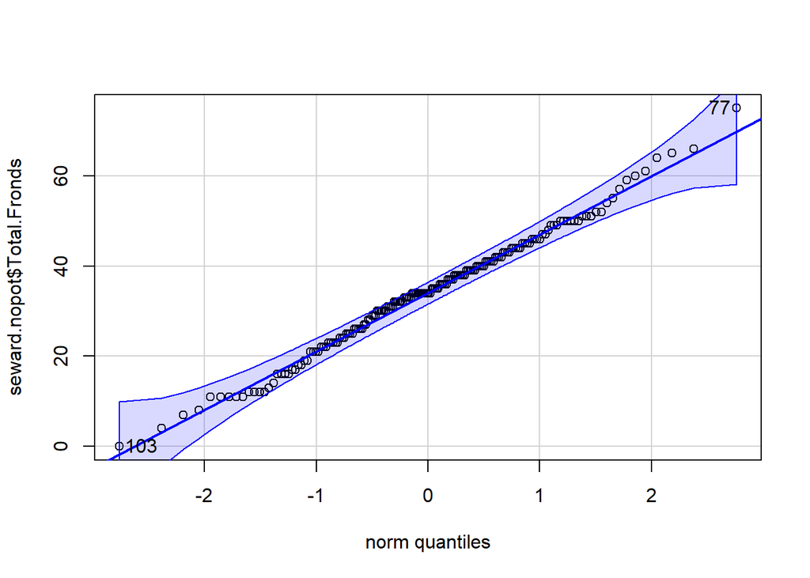

```
## [1]  77 103
```

```r
qqPlot(seward.nopot$Total.Fronds)
```

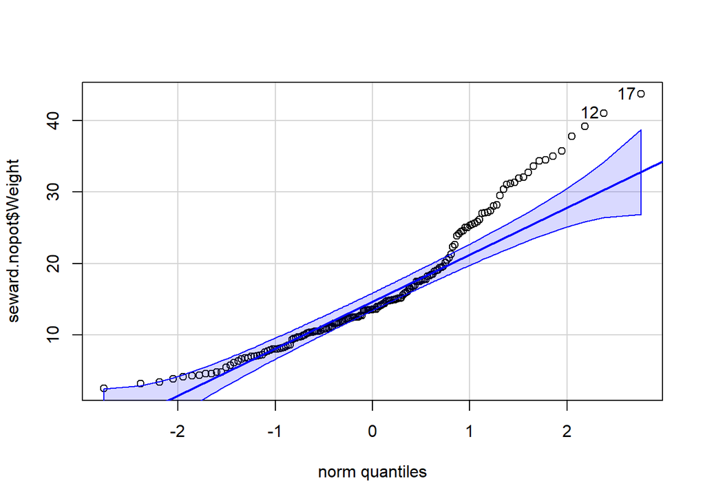

```
## [1] 17 12
```

```r
qqPlot(seward.nopot$Weight)
```

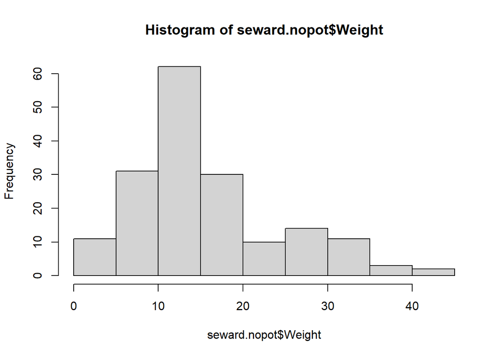

```r
hist(seward.nopot$Weight)
```

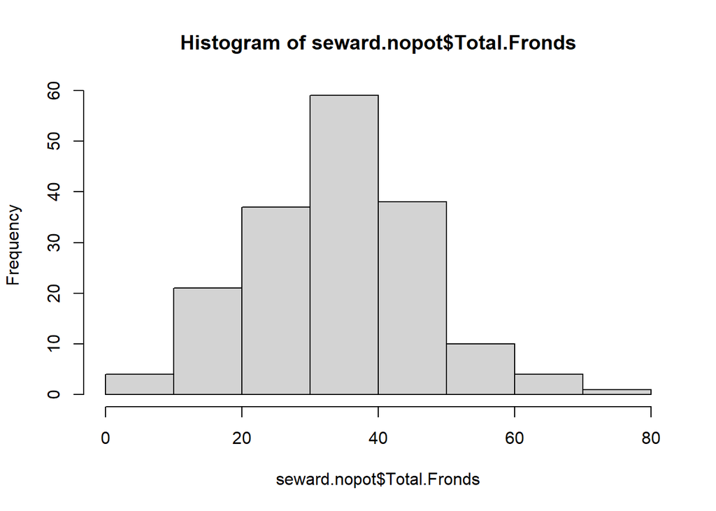

```r
hist(seward.nopot$Total.Fronds)
```

```r
seward.log <- seward.nopot %>% mutate(log_total = log1p(Total.Fronds),
                                        log_weight = log1p(Weight))

seward.test <- seward.log %>% dplyr::select(log_weight, log_total)
mshapiro.test(seward.test)
```

```
##
##  Multivariate Shapiro-Wilk normality test
##
## data:  (log_weight,log_total)
## W = 0.82928, p-value = 5.389e-13
```

```r
seward.nopot %>% shapiro_test(Total.Fronds, Weight)
```

```
## # A tibble: 2 × 3
##   variable     statistic            p
##   <chr>            <dbl>        <dbl>
## 1 Total.Fronds     0.993 0.606
## 2 Weight           0.918 0.0000000278
```

qqPlot and histogram for the number of total fronds are visually normally distributed. qqplot and histogram for the dried root weight are visually not normally distributed, therefore we cannot perform a MANOVA. Instead, we will perform a non-parametric ANOVA type test from the npmv R package (Burchett et al, 2017) as this is a non-parametric statistical test that does not require data to be normally distributed. This is further confirmed by performing the Multivariate Shapiro-Wilk normality test on the natural logarithm of one plus our sample data which suggests that our distribution of data for the dried root weight and total number of fronds is not normal (p-value = 5.389e-13 < 0.05).

### Run Nonparametric Inference for Multivariate Data on Seward dataset

```r
#install.packages("npmv")
library(npmv)

set.seed(123)
seward.npmv <- nonpartest(seward.nopot$Total.Fronds | seward.nopot$Weight ~ Treatment, data = seward.nopot, permtest = TRUE, plots = F, tests = c(1, 0, 0, 0), releffects = TRUE)
seward.npmv
```

```
## $results
##                                                   Test Statistic   df1      df2
## ANOVA type test p-value                                    4.437 1.747 300.5362
## McKeon approx. for the Lawley Hotelling Test                  NA    NA       NA
## Muller approx. for the Bartlett-Nanda-Pillai Test             NA    NA       NA
## Wilks Lambda                                                  NA    NA       NA
##                                                   P-value
## ANOVA type test p-value                             0.016
## McKeon approx. for the Lawley Hotelling Test           NA
## Muller approx. for the Bartlett-Nanda-Pillai Test      NA
## Wilks Lambda                                           NA
##                                                   Permutation Test p-value
## ANOVA type test p-value                                              0.019
## McKeon approx. for the Lawley Hotelling Test                            NA
## Muller approx. for the Bartlett-Nanda-Pillai Test                       NA
## Wilks Lambda                                                            NA
##
## $twogroupreleffects
##            seward.nopot$Total.Fronds seward.nopot$Weight
## Sterilized                   0.57292             0.60694
## Wild                         0.42708             0.39306
```

```r
seward.ss <- ssnonpartest(Total.Fronds | Weight ~ Treatment, data = seward.nopot, alpha = .05, factors.and.variables = FALSE)
```

```
## Rank Matrix is Singular, only ANOVA test can be calculated
##
## The ANOVA type statistic will be used in the following test
## The Global Hypothesis is significant, subset algorithm will continue
##
## ~Performing the Subset Algorithm based on Response Variables~
##  The Hypothesis of equality using response variables  Total.Fronds Weight is rejected
## The Hypothesis of equality using response variables  Weight is rejected
## All appropriate subsets using response variables have been checked using a multiple testing procedure, which controls the maximum overall type I error rate at alpha= 0.05
```

Only the ANOVA-type test was able to be performed in this instance as the rank matrix for our dataset is singular. After running the ANOVA type test with F approximation for each subset, the p-value 0.016 < 0.05, suggests there is a statistically significant difference in distributions for the total number of fronds and the dried root weight between treatment groups within our combined Seward trial datasets. The probability that a randomly chosen plant from the sterilized soil group exhibits a greater number of fronds than a randomly chosen plant from the trial is 0.57292. The probability that a randomly chosen plant from the sterilized soil group exhibits a greater root mass than a randomly chosen plant from the trial is 0.60694.

## Inoculation Trials

### Inoculation Data Cleaning and Filtering

```r
greenhouse.data <- greenhouse.data %>%
  mutate(Experiment = case_when(
    str_detect(`Trial.x`, "Inoculation") ~ "Inoculation",
    str_detect(`Trial.x`, "Seward") ~ "Seward Soil",
    TRUE ~ NA
  ))

greenhouse.data <- greenhouse.data %>%
  mutate(Treatment = case_when(
    str_detect(`Fern.Number`, "W[[:digit:]]") ~ "Wild",
    str_detect(`Fern.Number`, "NONE") ~ "No Agar No Rice",
    str_detect(`Fern.Number`, "BLA") ~ "Blank",
    str_detect(`Fern.Number`, "OCC") ~ "Phytophthora Occultans",
    str_detect(`Fern.Number`, "OBS") ~ "Phytophthora Obscura",
    str_detect(`Fern.Number`, "SYR") ~ "Phytophthora Syringae",
    str_detect(`Fern.Number`, "CAM") ~ "Phytophthora Cambivora",
    str_detect(`Fern.Number`, "CAC") ~ "Phytophthora Cactorum",
    str_detect(`Fern.Number`, "EUR") ~ "Phytophthora Europaea",
    str_detect(`Fern.Number`, "PLU") ~ "Phytophthora Plurivora",
    str_detect(`Fern.Number`, "CAM") ~ "Phytophthora Cambivora",
    str_detect(`Fern.Number`, "FLE") ~ "Phytophthora Flexuosa",
    str_detect(`Fern.Number`, "FLE") ~ "Phytophthora Flexuosa",
    str_detect(`Fern.Number`, "GIN") ~ "Globosporangium Intermedium",
    str_detect(`Fern.Number`, "C[[:digit:]]") ~ "Sterilized",
    str_detect(`Fern.Number`, "P[[:digit:]]") ~ "Control - Potting Mix",
    TRUE ~ NA
  ))

greenhouse.data <- subset(greenhouse.data, select = -c(Trial.y))
greenhouse.data <- greenhouse.data %>%
  mutate(Weight = replace_when(Weight,
    Fern.Number == "EURA062" ~ 5.3,
    Fern.Number == "EURA063" ~ 9.9,
    Fern.Number == "EURA064" ~ 2.72,
    Fern.Number == "SYRB013" ~ 4.15,
    Fern.Number == "SYRB014" ~ 5.39,
    Fern.Number == "SYRB015" ~ 4.56,
    Fern.Number == "SYRB016" ~ 5.75,
    Fern.Number == "SYRB017" ~ 14.75,
    Fern.Number == "SYRB018" ~ 8.76
      )
  )

inoc.data <- greenhouse.data %>% filter(Experiment == "Inoculation")
inoc1 <- inoc.data %>% filter(Trial.x == "Inoculation Trial One")
```

## Visualize Data

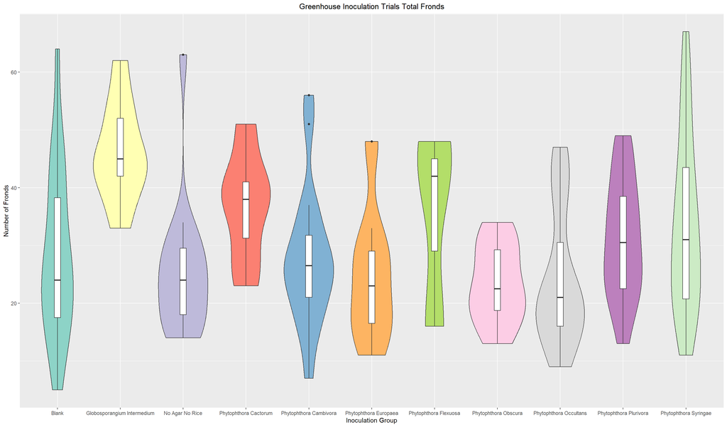

```r
total.inoc <- ggplot(inoc.data, aes(x = Treatment, y = Total.Fronds, fill = Treatment)) + geom_violin() + geom_boxplot(width=0.1, fill = "white") +
  labs(title = "Greenhouse Inoculation Trials Total Fronds", y = "Number of Fronds", x= "Inoculation Group") + theme(plot.title = element_text(hjust = 0.5), legend.position = "none")
total.inoc + scale_fill_brewer(palette = "Set3")
```

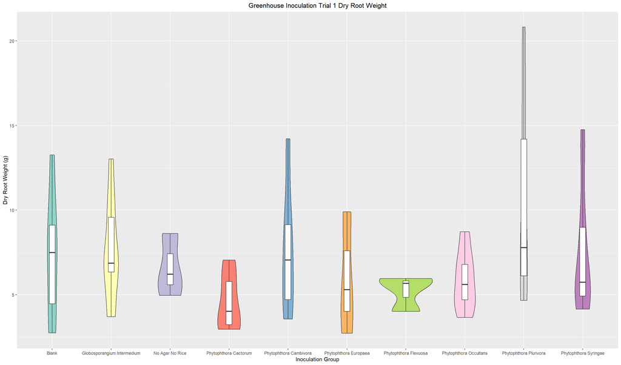

```r
weight.inoc1 <- ggplot(inoc1, aes(x = Treatment, y = Weight, fill = Treatment)) + geom_violin() + geom_boxplot(width=0.1, fill = "white") +
  labs(title = "Greenhouse Inoculation Trial 1 Dry Root Weight", y = "Dry Root Weight (g)", x= "Inoculation Group") + theme(plot.title = element_text(hjust = 0.5), legend.position = "none")
weight.inoc1 + scale_fill_brewer(palette = "Set3")
```

## Inoculation Trial 1

### Check data for equality of variances

```r
leveneTest(Total.Fronds ~ as.factor(Treatment), data = inoc1, na.rm =  TRUE)
```

```
## Levene's Test for Homogeneity of Variance (center = median: TRUE)
##       Df F value Pr(>F)
## group  9  0.6244 0.7706
##       50
```

```r
leveneTest(Weight ~ as.factor(Treatment), data = inoc1, na.rm = TRUE)
```

```
## Levene's Test for Homogeneity of Variance (center = median: TRUE)
##       Df F value Pr(>F)
## group  9  1.1222 0.3651
##       50
```

Not enough evidence to reject equality of variances between treatments based on the total number of fronds or dry root weight.

### Check normality

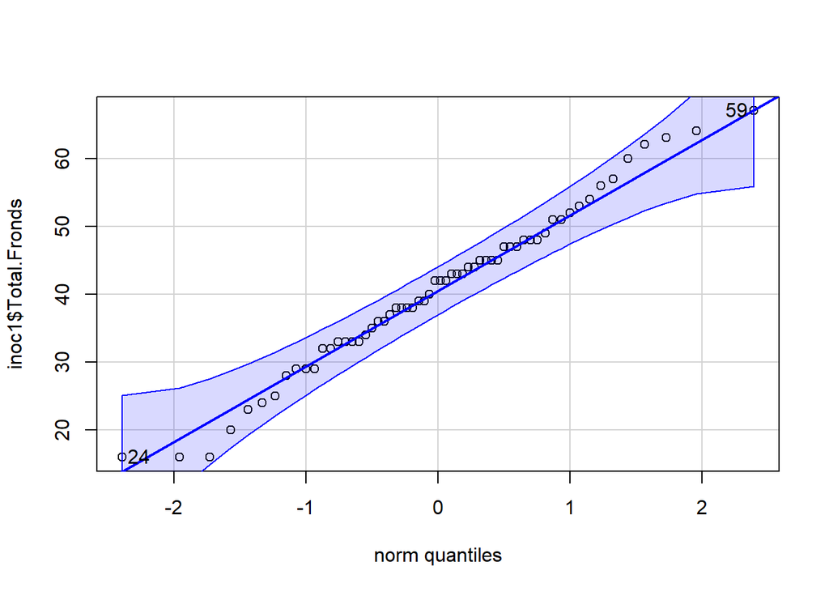

```
## [1] 59 24
```

```r
qqPlot(inoc1$Total.Fronds)
```

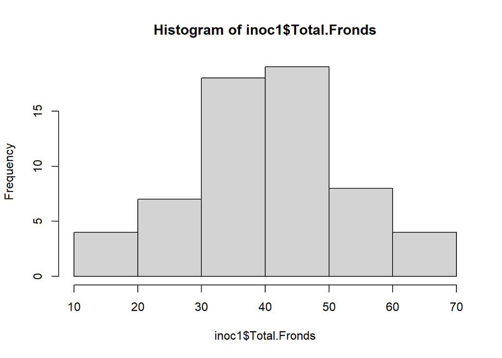

```r
hist(inoc1$Total.Fronds)
```

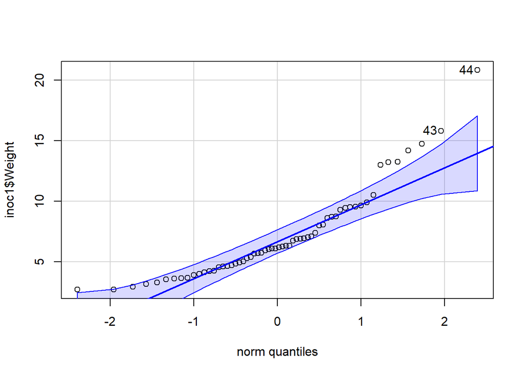

```
## [1] 44 43
```

```r
qqPlot(inoc1$Weight)
```

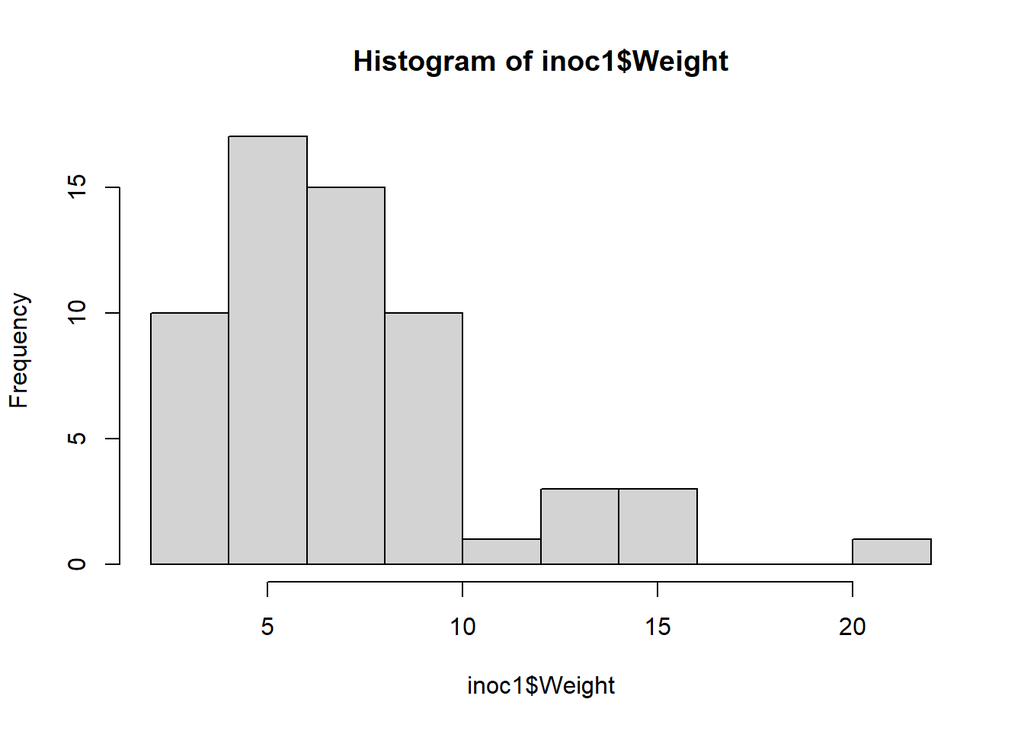

```r
hist(inoc1$Weight)
```

```r
inoc1 %>% shapiro_test(Total.Fronds, Weight)
```

```
## # A tibble: 2 × 3
##   variable     statistic         p
##   <chr>            <dbl>     <dbl>
## 1 Total.Fronds     0.986 0.732
## 2 Weight           0.870 0.0000127
```

```r
misty::descript(inoc1$Total.Fronds)
```

```
##  Descriptive Statistics
##
##    n nNA %NA nUQ     M    SD   Min  %Min   Max  %Max  Skew  Kurt
##   60   0  0%  34 40.77 11.95 16.00 5.00% 67.00 1.67% -0.03 -0.25
```

```r
misty::descript(inoc1$Weight)
```

```
##  Descriptive Statistics
##
##    n nNA %NA nUQ    M   SD  Min  %Min   Max  %Max Skew Kurt
##   60   0  0%  59 7.08 3.63 2.72 1.67% 20.82 1.67% 1.48 2.44
```

After visually checking QQ plot and histogram, the distribution for the total number of fronds for our inoculation trials data appear to be normal. To confirm a Shapiro-Wilk test was performed which yielded a non-significant result, suggesting there is not enough evidence to reject the normality of the dataset. Dry swordfern root weight data not normally distributed according to visual inspection using qqPlot and histogram and the Shapiro-Wilk test for normality.

```r
set.seed(123)
seward.npmv <- nonpartest(inoc1$Total.Fronds | inoc1$Weight ~ Treatment, data = inoc1, permtest = TRUE, plots = F, tests = c(1, 1, 1, 1), releffects = TRUE)
seward.npmv
```

```
## $results
##                                                   Test Statistic    df1
## ANOVA type test p-value                                    0.611 16.206
## McKeon approx. for the Lawley Hotelling Test               0.884 18.000
## Muller approx. for the Bartlett-Nanda-Pillai Test          0.896 18.936
## Wilks Lambda                                               0.895 18.000
##                                                        df2 P-value
## ANOVA type test p-value                            66.3001   0.865
## McKeon approx. for the Lawley Hotelling Test       77.9726   0.599
## Muller approx. for the Bartlett-Nanda-Pillai Test 103.4483   0.589
## Wilks Lambda                                       98.0000   0.585
##                                                   Permutation Test p-value
## ANOVA type test p-value                                              0.816
## McKeon approx. for the Lawley Hotelling Test                         0.593
## Muller approx. for the Bartlett-Nanda-Pillai Test                    0.565
## Wilks Lambda                                                         0.580
##
## $releffects
##                             inoc1$Total.Fronds inoc1$Weight
## Blank                                  0.59028      0.52778
## Globosporangium Intermedium            0.63519      0.58611
## No Agar No Rice                        0.40278      0.51944
## Phytophthora Cactorum                  0.39306      0.26528
## Phytophthora Cambivora                 0.45139      0.53750
## Phytophthora Europaea                  0.58889      0.40833
## Phytophthora Flexuosa                  0.43056      0.33611
## Phytophthora Occultans                 0.35417      0.43611
## Phytophthora Plurivora                 0.41250      0.66667
## Phytophthora Syringae                  0.56736      0.52778
```

No statistically significant difference in distributions between treatment groups for the total number of fronds and dry root weight for the first inoculation trial.

## Inoculation Trail 2 Data

```r
inoc2 <- inoc.data %>% filter(Trial.x == "Inoculation Trial Two")
leveneTest(Total.Fronds ~ as.factor(Treatment), data = inoc2, na.rm =  TRUE)
```

```
## Levene's Test for Homogeneity of Variance (center = median: TRUE)
##       Df F value Pr(>F)
## group  7  0.2696 0.9641
##       88
```

Not enough evidence to reject equality of variances between treatments based on the total number of fronds.

### Check normality

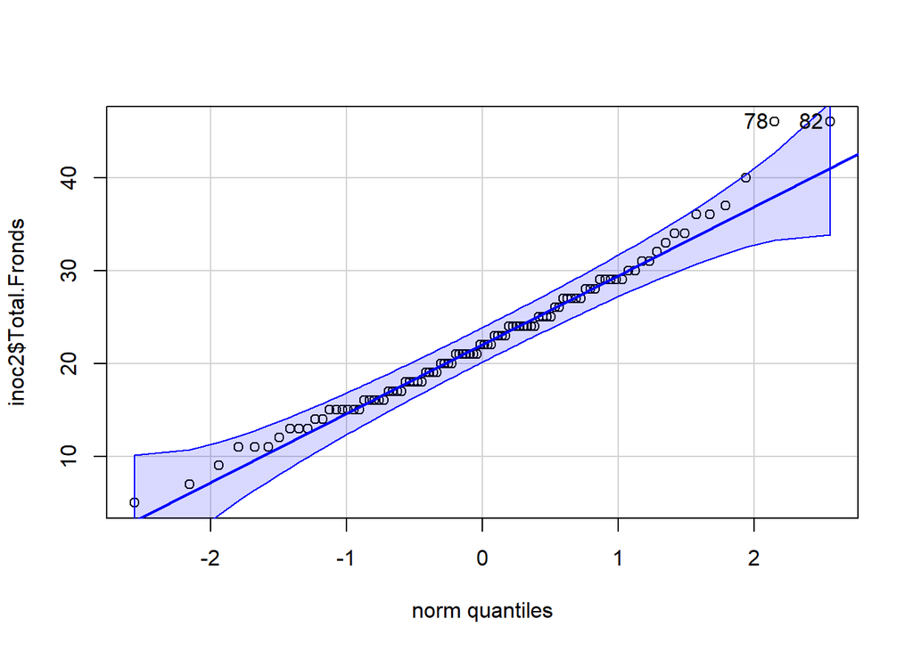

```
## [1] 78 82
```

```r
qqPlot(inoc2$Total.Fronds)
```

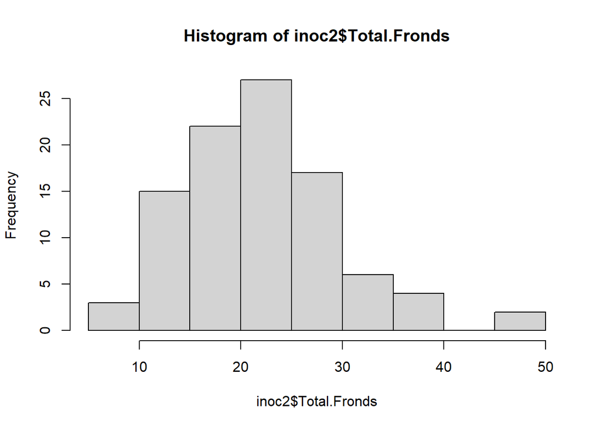

```r
hist(inoc2$Total.Fronds)
```

```r
inoc2 %>% shapiro_test(Total.Fronds)
```

```
## # A tibble: 1 × 3
##   variable     statistic      p
##   <chr>            <dbl>  <dbl>
## 1 Total.Fronds     0.977 0.0924
```

After visually checking QQ plot and histogram, the distribution for the total number of fronds for our inoculation trials data appear to be normal. To confirm a Shapiro-Wilk test was performed which yielded a non-significant result, suggesting the data is normal.

### Conduct ANOVA on Trial 2 Data

```r
anova.inoc2 <- oneway.test(`Total.Fronds` ~ Treatment, data = inoc2 ,var.equal = TRUE)
anova.inoc2
```

```
##
##  One-way analysis of means
##
## data:  Total.Fronds and Treatment
## F = 1.2956, num df = 7, denom df = 88, p-value = 0.2619
```

## Combined Trial Data

### Check data for equality of variances

```r
leveneTest(Total.Fronds ~ as.factor(Treatment), data = inoc.data, na.rm =  TRUE)
```

```
## Levene's Test for Homogeneity of Variance (center = median: TRUE)
##        Df F value Pr(>F)
## group  10  0.8965 0.5382
##       145
```

Not enough evidence to reject equality of variances between treatments based on the total number of fronds.

### Check normality

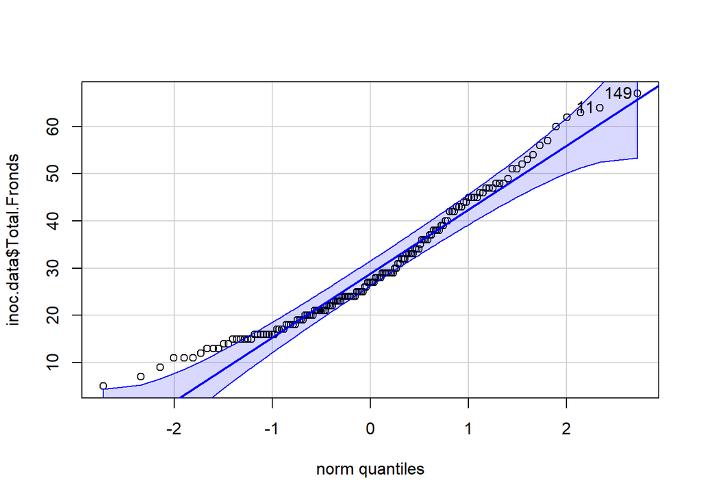

```
## [1] 149  11
```

```r
qqPlot(inoc.data$Total.Fronds)
```

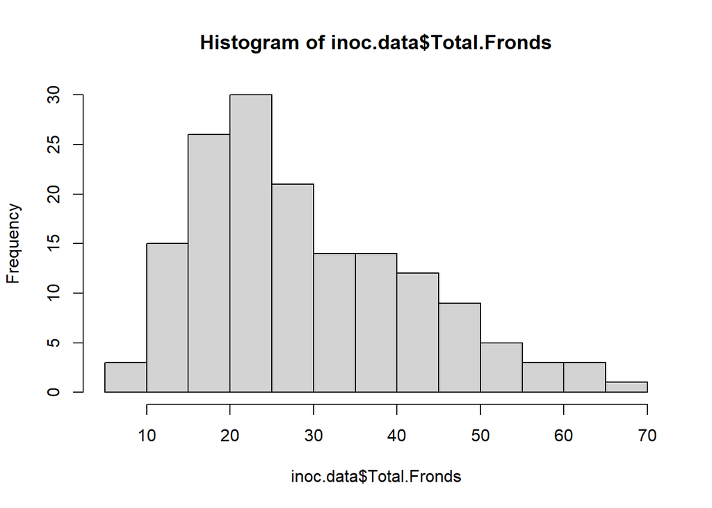

```r
hist(inoc.data$Total.Fronds)
```

```r
inoc.data %>% shapiro_test(Total.Fronds)
```

```
## # A tibble: 1 × 3
##   variable     statistic         p
##   <chr>            <dbl>     <dbl>
## 1 Total.Fronds     0.954 0.0000524
```

After visually checking QQ plot and histogram, the distribution for the total number of fronds for our inoculation trials data appear to be non-normal. To confirm a Shapiro-Wilk test was performed which yielded a significant result, suggesting the data is not normal.

### Run non-parametric Kruskal-Wallis test

```r
kruskal.test(Total.Fronds ~ Treatment, data = inoc.data)
```

```
##
##  Kruskal-Wallis rank sum test
##
## data:  Total.Fronds by Treatment
## Kruskal-Wallis chi-squared = 28.199, df = 10, p-value = 0.001677
```

```r
library(FSA)
dunnTest(Total.Fronds ~ Treatment,
         data = inoc.data,
         method = "holm")
```

```
##   Kruskal-Wallis rank sum test
##
## data: x and g
```

```
## Kruskal-Wallis chi-squared = 28.1992, df = 10, p-value = 0
```

```
##
##                      Dunn's Pairwise Comparison of x by g
##                                     (Holm)
## Col Mean-│
## Row Mean │      Blank   Globospo   No Agar    Phytopht   Phytopht   Phytopht
## ─────────┼──────────────────────────────────────────────────────────────────
## Globospo │  -3.146240
##          │     0.0843
##          │
## No Agar  │   0.636266   3.573898
##          │     1.0000     0.0183*
##          │
## Phytopht │  -1.615521   0.992101  -2.037083
##          │     1.0000     1.0000     1.0000
##          │
## Phytopht │  -0.001845   3.144733  -0.638026   1.614216
##          │     0.9985     0.0831     1.0000     1.0000
##          │
## Phytopht │   0.727061   3.649181   0.086929   2.102795   0.728820
##          │     1.0000     0.0139*    1.0000     1.0000     1.0000
##          │
## Phytopht │  -0.783237   1.194019  -1.123992   0.386263  -0.782251  -1.174180
##          │     1.0000     1.0000     1.0000     1.0000     1.0000     1.0000
##          │
## Phytopht │   0.897947   3.671756   0.289711   2.192418   0.899598   0.207753
##          │     1.0000     0.0130*    1.0000     1.0000     1.0000     1.0000
##          │
## Phytopht │   1.116509   4.057866   0.428283   2.405012   1.118354   0.337488
##          │     1.0000     0.0027*    1.0000     0.7924     1.0000     1.0000
##          │
## Phytopht │  -0.948571   2.371734  -1.540694   0.944779  -0.946726  -1.631488
##          │     1.0000     0.8321     1.0000     1.0000     1.0000     1.0000
##          │
## Phytopht │  -1.146249   2.371750  -1.761700   0.885465  -1.144276  -1.858140
##          │     1.0000     0.8498     1.0000     1.0000     1.0000     1.0000
## Col Mean-│
## Row Mean │   Phytopht   Phytopht   Phytopht   Phytopht
## ─────────┼────────────────────────────────────────────
## Phytopht │   1.275109
##          │     1.0000
##          │
## Phytopht │   1.380037   0.100688
##          │     1.0000     1.0000
##          │
## Phytopht │   0.276204  -1.746375  -2.065081
##          │     1.0000     1.0000     1.0000
##          │
## Phytopht │   0.213968  -1.957416  -2.339848  -0.132183
##          │     1.0000     1.0000     0.8874     1.0000
##
## FWER = 0.05
## Reject Ho if p ≤ FWER with stopping rule, where p = Pr(|Z| ≥ |z|)
## Dunn (1964) Kruskal-Wallis multiple comparison
##
##   p-values adjusted with the Holm method.
```

```
##                                              Comparison           Z
## 1                   Blank - Globosporangium Intermedium -3.14624048
## 2                               Blank - No Agar No Rice  0.63626660
## 3         Globosporangium Intermedium - No Agar No Rice  3.57389864
## 4                         Blank - Phytophthora Cactorum -1.61552133
## 5   Globosporangium Intermedium - Phytophthora Cactorum  0.99210119
## 6               No Agar No Rice - Phytophthora Cactorum -2.03708334
## 7                        Blank - Phytophthora Cambivora -0.00184547
## 8  Globosporangium Intermedium - Phytophthora Cambivora  3.14473366
## 9              No Agar No Rice - Phytophthora Cambivora -0.63802619
## 10       Phytophthora Cactorum - Phytophthora Cambivora  1.61421638
## 11                        Blank - Phytophthora Europaea  0.72706128
## 12  Globosporangium Intermedium - Phytophthora Europaea  3.64918161
## 13              No Agar No Rice - Phytophthora Europaea  0.08692929
## 14        Phytophthora Cactorum - Phytophthora Europaea  2.10279571
```

[output cut: 97 more lines]

Reject the null hypothesis and we conclude that at least one group is different in terms of number of total fronds (p-value = 0.001677). To determine which groups significantly differ a Dunn’s pairwise comparison post-hoc test using the Holm method was conducted. The groups that have significantly different number of fronds according to this test are the no agar no rice group compared to the globosporangium intermedium group, globosporangium intermedium group compared to the phytophthora europaea group, globosporangium intermedium compared to the phytophthora obscura group, and globosporangium intermedium compared to the phytophthora occultans group.